# Problem Set 4

Uncertainty

[YOUR NAME]

Due Date: 2024-11-15

## Getting Set Up

Open `RStudio` and create a new RMarkDown file (`.Rmd`) by going to `File -> New File -> R Markdown...`. Accept defaults and save this file as `[LAST NAME]_ps4.Rmd` to your `code` folder.

Copy and paste the contents of this `.Rmd` file into your `[LAST NAME]_ps4.Rmd` file. Then change the `author: [Your Name]` to your name.

We will be using two datasets this week. The first is the `game_summary.Rds` file from the course [github page](https://github.com/rweldzius/PSC7000_F2024/blob/main/Data/game_summary.Rds) and should be saved to an object called `games`.

All of the following questions should be answered in this `.Rmd` file. There are code chunks with incomplete code that need to be filled in. To submit, compile (i.e., `knit`) the completed problem set and upload the PDF file to Blackboard on Friday by midnight. Instructions for how to compile the output as a PDF can be found in [Problem Set 0](https://github.com/rweldzius/PSC7000_F2024/blob/main/Psets/psc7000_pset_0.pdf) and in this [gif tutorial](https://github.com/rweldzius/PSC7000_F2024/blob/main/Psets/save_as_pdf.gif).

This problem set is worth 5 total points, plus 1 extra credit point. The point values for each question are indicated in brackets below. To receive full credit, you must have the correct code. In addition, some questions ask you to provide a written response in addition to the code.

You will be deducted 1 point for each day late the problem set is submitted, and 1 point for failing to submit in the correct format.

You are free to rely on whatever resources you need to complete this problem set, including lecture notes, lecture presentations, Google, your classmates…you name it. However, the final submission must be complete by you. There are no group assignments.

*Note that the professor will not respond to Campuswire posts after 5PM on Friday, so don’t wait until the last minute to get started!*

**Good luck!**

*Copy the link to ChatGPT you used here: _________________ (or print the output from your session and upload to Blackboard)

## Question 0

Require `tidyverse` and load the [`game_summary.rds`](https://github.com/rweldzius/PSC7000_F2024/blob/main/Data/game_summary.Rds?raw=true) data to an object called `games`.

```r
require(tidyverse)
games <- read_rds('https://github.com/rweldzius/PSC7000_F2024/blob/main/Data/game_summary.Rds?raw=true')
```

## Question 1 [1 point]

How many points, on average, did the Philadelphia 76ers score at home and away games in the 2017 season? Calculate this answer and also plot the multivariate relationship. Explain why your chosen visualization is justified. Draw two vertical lines for the average points at home and away. (+0.25 extra credit for those who can also add the label for the average points above each vertical line.)

```r
(vertLines <- games %>%
filter(yearSeason == 2017,
       nameTeam == 'Philadelphia 76ers') %>% # Filter to the 2017 season (yearSeason) AND to the Philadelphia 76ers (nameTeam)
  group_by(locationGame) %>% # Group by the location of the game (locationGame)
  summarise(avg_pts = mean(pts,na.rm=T))) # Calculate the average points (pts)
```

```
## # A tibble: 2 × 2
##   locationGame avg_pts
##   <chr>          <dbl>
## 1 A               102.
## 2 H               102.
```

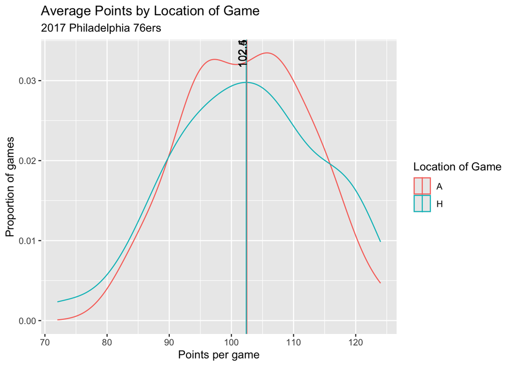

```r
games %>%
  filter(yearSeason == 2017,
         nameTeam == 'Philadelphia 76ers') %>% # Filter to the 2017 season (yearSeason) AND to the Philadelphia 76ers (nameTeam)
  ggplot(aes(x = pts,color = locationGame)) + # Create a multivariate plot comparing points scored between home and away games
  geom_density() + # Choose the appropriate geom_... for this plot (i.e., geom_histogram(), geom_density(), geom_bar(), etc.)
  labs(title = 'Average Points by Location of Game', # Add clear descriptions for the title, subtitle, axes, and legend
       subtitle = '2017 Philadelphia 76ers',
       x = 'Points per game',
       y = 'Proportion of games',
       color = 'Location of Game') +
  geom_vline(data = vertLines,aes(xintercept = avg_pts,color = locationGame)) + # Add vertical lines for the average points scored at home and away.
  annotate(geom = 'text',x = vertLines$avg_pts,y = Inf,label = round(vertLines$avg_pts,1),vjust = 0,hjust = 1,angle = 90) # EC: label the vertical lines
```

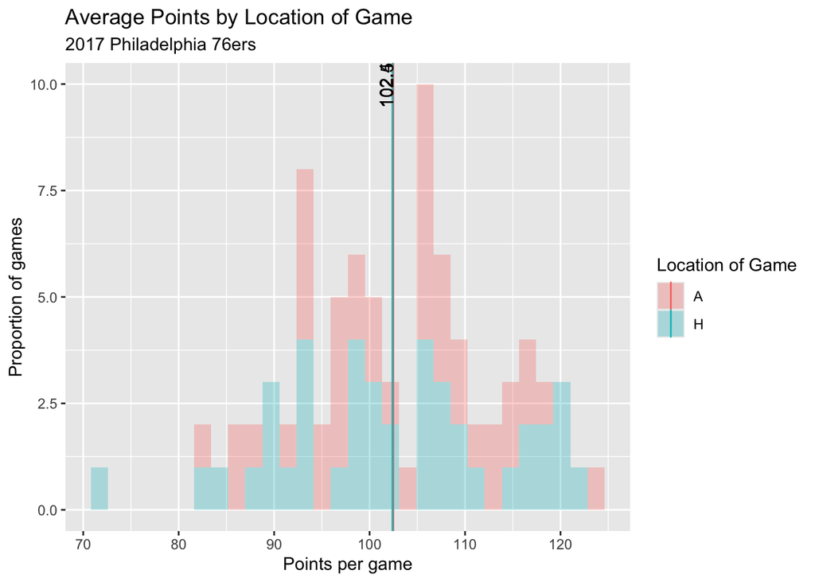

```r
games %>%
  filter(yearSeason == 2017,
         nameTeam == 'Philadelphia 76ers') %>%
  ggplot(aes(x = pts,fill = locationGame)) +
  geom_histogram(alpha = .3) +
  labs(title = 'Average Points by Location of Game',
       subtitle = '2017 Philadelphia 76ers',
       x = 'Points per game',
       y = 'Proportion of games',
       fill = 'Location of Game',
       color = 'Location of Game') +
  geom_vline(data = vertLines,aes(xintercept = avg_pts,color = locationGame)) +
  annotate(geom = 'text',x = vertLines$avg_pts,y = Inf,label = round(vertLines$avg_pts,1),vjust = 0,hjust = 1,angle = 90)
```

> I chose a geom_density that was colored by the location of the game. I could have also chosen a histogram. [RUBRIC: -0.25 points if: vertical lines are not present; vertical lines do not represent the 2017 Philadelphia 76ers; vertical lines do not clearly indicate home versus away. -0.5 points if: no labels; wrong geom; no explanation of choice of geom.]

## Question 2 [1 point]

Now recreate the same plot but show all three seasons side by side (hint: use `facet_wrap()`). Imagine that you work for the 76ers organization and Daryl Morey (the GM), asks you if the team scores more points at home or away? Based on your analysis, what would you tell him?

```r
# By season
(vertLines <- games %>%
filter(nameTeam == 'Philadelphia 76ers') %>% # Filter to the Philadelphia 76ers (nameTeam)
  group_by(locationGame,yearSeason) %>% # Group by the location (locationGame) and the season (yearSeason)
  summarise(avg_pts = mean(pts,na.rm=T))) # Calculate the average points (pts)
```

```
## # A tibble: 6 × 3
## # Groups:   locationGame [2]
##   locationGame yearSeason avg_pts
##   <chr>             <int>   <dbl>
## 1 A                  2017    102.
## 2 A                  2018    108
## 3 A                  2019    112.
## 4 H                  2017    102.
## 5 H                  2018    112.
## 6 H                  2019    118.
```

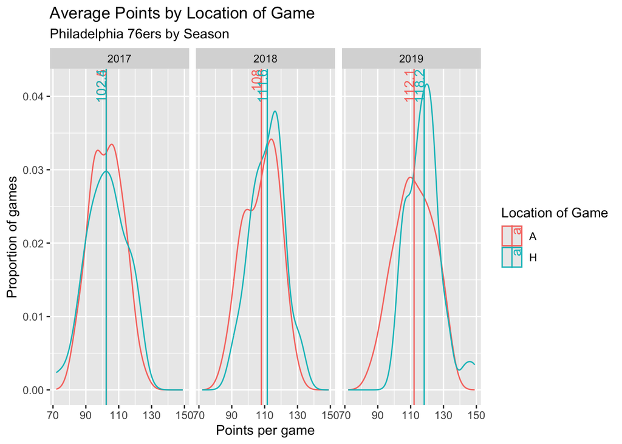

```r
games %>%
  filter(nameTeam == 'Philadelphia 76ers') %>% # Filter to the 2017 season (yearSeason) AND to the Philadelphia 76ers (nameTeam)
  ggplot(aes(x = pts,color = locationGame)) + # Create a multivariate plot comparing points scored between home and away games
  geom_density() + # Choose the appropriate geom_... for this plot (i.e., geom_histogram(), geom_density(), geom_bar(), etc.)
  labs(title = 'Average Points by Location of Game', # Add clear descriptions for the title, subtitle, axes, and legend
       subtitle = 'Philadelphia 76ers by Season',
       x = 'Points per game',
       y = 'Proportion of games',
       color = 'Location of Game') +
  facet_wrap(~yearSeason) + # Create separate panels for each season (facet_wrap())
  geom_vline(data = vertLines,aes(xintercept = avg_pts,color = locationGame)) +
  geom_text(data = vertLines,aes(x = avg_pts,y = Inf,color = locationGame,label = round(avg_pts,1)),
            vjust = 0,hjust = 1,angle = 90)
```

## Question 3 [1 point]

Daryl Morey thanks you for your answer, but is a well-trained statistician in his own right, and wants to know how confident you are in your claim. Bootstrap sample the data 1,000 times to provide him with a more sophisticated answer. How confident are you in your conclusion that the 76ers score more points at home games than away games? Across 1,000 bootstrap simulations, what is the average point difference between home and away games? Make sure to `set.seed(123)` to ensure you get the same answer every time you `knit` your code!

```r
set.seed(123) # Set the seed to 123!
forBS <- games %>% # To make things easier, create a new data object that is filtered to just the Celtics
    filter(nameTeam == 'Philadelphia 76ers') # Filter to the Celtics (nameTeam)

bsRes <- NULL # Instantiate an empty object to store data from the loop
for(i in 1:1000) { # Loop 1,000 times
  bsRes <- forBS %>%
    sample_n(size = nrow(forBS),replace = T) %>% # Sample the data with replacement using all possible rows
    group_by(locationGame) %>% # Group by the location of the game (locationGame)
    summarise(avg_pts = mean(pts,na.rm=T)) %>% # Calculate the average points (pts)
    ungroup() %>% # Best practices!
    mutate(bsInd = i) %>% # Save the bootstrap index
    bind_rows(bsRes) # Append the result to the empty object from above
}

# Calculate the confidence
bsRes %>%
  pivot_wider(names_from = locationGame,
              values_from = avg_pts) %>% # Spread the data to get one column for average points at home and another for average points away
  mutate(diff = H - A) %>%
  summarise(confidence = mean(diff > 0), # Calculate the proportion of bootstrap simulations where the home points are greater than the away points
            avg_diff = mean(diff)) # Calculate the overall average difference
```

```
## # A tibble: 1 × 2
##   confidence avg_diff
##        <dbl>    <dbl>
## 1      0.986     3.18
```

## Question 4 [1 point]

Visualize the bootstrapped results in two ways. First, plot the home and away simulations as densities with vertical lines for their averages, following the approach used in Questions 1 and 2 above. Second, plot the difference between home and away as a single density, with a vertical line at zero for reference.

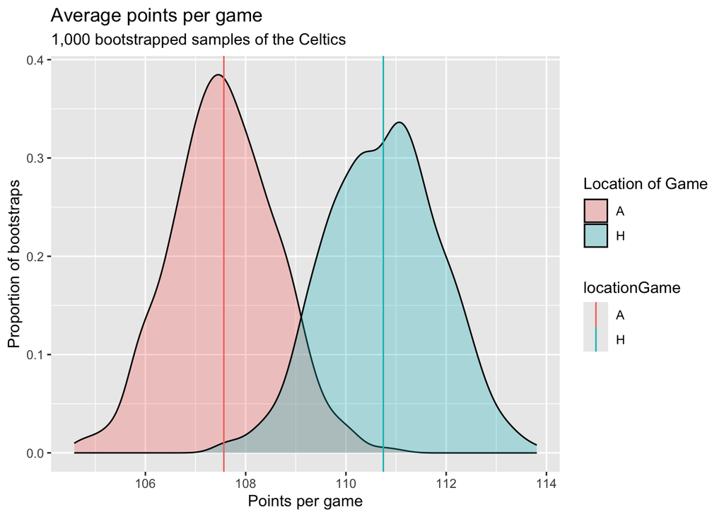

```r
bsRes %>%
  ggplot(aes(x = avg_pts,
             fill = locationGame)) +
  geom_density(alpha=0.3) +
  geom_vline(data = bsRes %>%
               group_by(locationGame) %>%
               summarise(avg_pts = mean(avg_pts)),
             aes(xintercept = avg_pts,color = locationGame)) +
  labs(title = 'Average points per game', # Add clear descriptions for the title, subtitle, axes, and legend
       subtitle = '1,000 bootstrapped samples of the Celtics',
       x = 'Points per game',
       y = 'Proportion of bootstraps',
       fill = 'Location of Game')
```

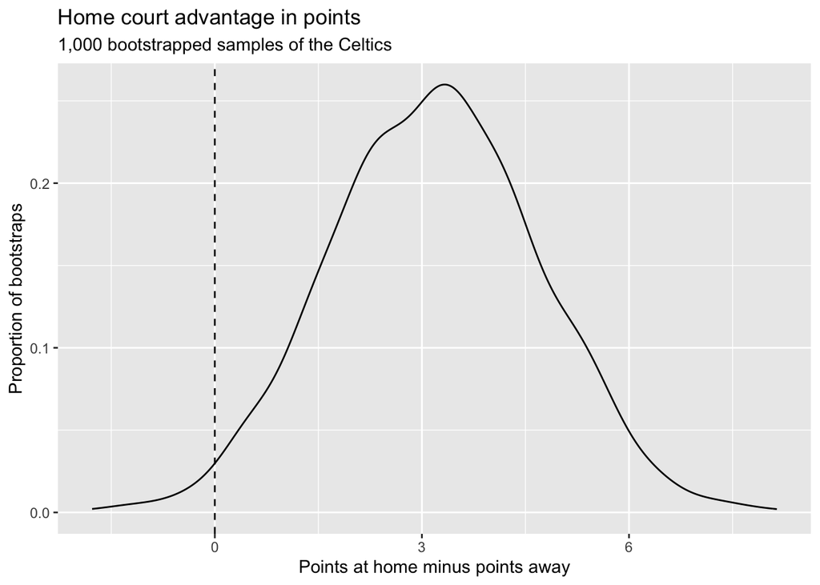

```r
bsRes %>%
  pivot_wider(names_from = locationGame,
              values_from = avg_pts) %>%
  mutate(diff = H-A) %>%
  ggplot(aes(x = diff)) +
  geom_density() +
  geom_vline(xintercept = 0,linetype = 'dashed') +
  labs(title = 'Home court advantage in points', # Add clear descriptions for the title, subtitle, axes, and legend
       subtitle = '1,000 bootstrapped samples of the Celtics',
       x = 'Points at home minus points away',
       y = 'Proportion of bootstraps')
```

> [RUBRIC: -0.25 points for: errors in creating the vertical lines for the first plot, errors in calculating the home court advantange measure in the second plot. -0.5 points for: no labels.]

## Question 5 [1 point]

Re-do the analysis from question 3 for three other statistics of interest to Brad: total rebounds (treb), turnovers (tov), and field goal percent (pctFG). Do you notice anything strange in these results? What might explain it?

```r
set.seed(123)
bsRes <- NULL # Instantiate an empty object to store data from the loop
for(i in 1:1000) { # Loop 1,000 times
  bsRes <- forBS %>%
    sample_n(size = nrow(forBS),replace = T) %>% # Sample the data with replacement using all possible rows
    group_by(locationGame) %>% # Group by the location of the game (locationGame)
    summarise(avg_reb = mean(treb,na.rm=T), # Calculate the average total rebounds (treb)
              avg_tov = mean(tov,na.rm=T), # Calculate the average turnovers (tov)
              avg_pctFG = mean(pctFG,na.rm=T)) %>% # Calculate the average field goal shooting percentage (pctFG)
    ungroup() %>% # Best practices!
    mutate(bsInd = i) %>% # Save the bootstrap index
    bind_rows(bsRes) # Append the result to the empty object from above
}

# Calculate the confidence
bsRes %>%
  pivot_wider(names_from = locationGame, # Pivot wider to get each measure in its own colunm for homme and away games
                values_from = c('avg_reb','avg_tov','avg_pctFG')) %>% # Use the values from the variables you created above
    mutate(diff_reb = avg_reb_H - avg_reb_A, # Calculate the difference between home and away total rebounds
           diff_tov = avg_tov_H - avg_tov_A, # Calculate the difference between home and away turnovers
           diff_pctFG = avg_pctFG_H - avg_pctFG_A) %>%
  summarise(confidence_reb = mean(diff_reb > 0),
            confidence_tov = mean(diff_tov > 0),
            confidence_pctFG = mean(diff_pctFG > 0),
            avg_reb = mean(diff_reb),
            avg_tov = mean(diff_tov),
            avg_pctFG = mean(diff_pctFG))
```

```
## # A tibble: 1 × 6
##   confidence_reb confidence_tov confidence_pctFG avg_reb avg_tov avg_pctFG
##            <dbl>          <dbl>            <dbl>   <dbl>   <dbl>     <dbl>
## 1           0.91          0.015            0.862    1.18   -1.14    0.0101
```

## Extra Credit [1 point]

Now Brad is asking for a similar analysis of other teams. Calculate the difference between home and away points for every team in the league and prepare a summary table that includes both the average difference for each team, as well as your confidence about whether the difference is not zero. Based on these data, would you argue that there is an **overall** home court advantage in terms of points across the NBA writ large? Visualize these summary results by plotting the difference on the x-axis, the teams (reordered) on the y-axis, and the points colored by whether you are more than 90% confident in your answer. How should we interpret confidence levels less than 50%?

```r
set.seed(123)
bsRes <- NULL # Instantiate an empty object to store data from the loop
for(i in 1:1000) { # Loop 1,000 times
  bsRes <- games %>%
    group_by(nameTeam) %>%
    sample_n(size = n(),replace = T) %>% # Sample the data with replacement using all possible rows
    group_by(locationGame,nameTeam) %>% # Group by the location of the game (locationGame)
    summarise(avg_pts = mean(pts,na.rm=T),.groups = 'drop') %>% # Calculate the average turnovers (tov)
    pivot_wider(id_cols = nameTeam,
                names_from = locationGame, # Pivot wider to get each measure in its own column for home and away games
                values_from = c('avg_pts')) %>% # Use the values from the variables you created above
    mutate(diff = H - A, # Calculate the difference between home and away turnovers
           bsInd = i) %>% # Save the bootstrap index
    bind_rows(bsRes) # Append the result to the empty object from above
}

(toplot <- bsRes %>%
  group_by(nameTeam) %>%
  summarise(conf = round(mean(diff > 0),2),
            diff = round(mean(diff),2)))
```

```
## # A tibble: 30 × 3
##    nameTeam               conf  diff
##    <chr>                 <dbl> <dbl>
##  1 Atlanta Hawks          1     4.37
##  2 Boston Celtics         0.99  3.01
##  3 Brooklyn Nets          0.42 -0.43
##  4 Charlotte Hornets      0.99  3.86
##  5 Chicago Bulls          0.49 -0.04
##  6 Cleveland Cavaliers    0.94  2.45
##  7 Dallas Mavericks       0.98  2.99
##  8 Denver Nuggets         1     4.88
##  9 Detroit Pistons        0.99  3.41
## 10 Golden State Warriors  0.9   2.04
## # ℹ 20 more rows
```

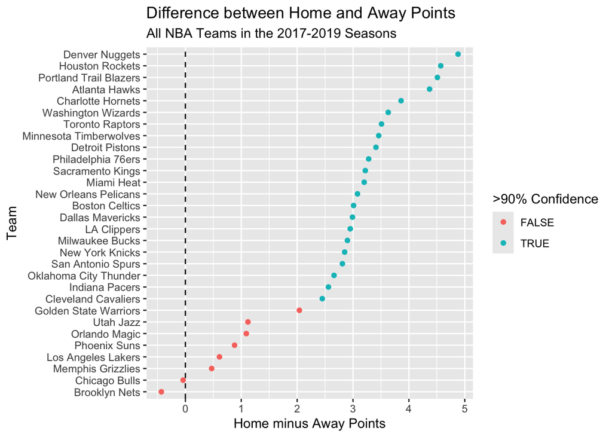

```r
toplot %>%
  ggplot(aes(x = diff,y = reorder(nameTeam,diff),color = conf > .9 | conf < .1))+
  geom_point() +
  geom_vline(xintercept = 0,linetype = 'dashed') +
  labs(title = 'Difference between Home and Away Points',
       subtitle = 'All NBA Teams in the 2017-2019 Seasons',
       x= 'Home minus Away Points',
       y = 'Team',
       color = '>90% Confidence')
```

> Here we find much stronger evidence that teams generally score more points at home than away games across the NBA. Every team except the Bulls and Nets score more points at home than away, and the majority of these differences we can confidently say are greater than zero at the 90% level. Confidence levels less than 50% mean that teams scored more home points than away points in fewer than 50% of simulated realities. This is equivalent to saying that they scored more away points than home points in more than 50% of simulated realities. In other words, if the confidence is less than 0.5, we can flip the statement and say we are 1-the confidence. [RUBRIC: -0.25 points if: the students are unable to color points by the confidence interval, they fail to include a vertical line at zero, they do not sample by each team, they do not calculate home and away points for each team. -0.5 points if: no labels on the plot.]